# Entrepreneurial behaviour

Participants of MSI are monitoring their entrepreneurial growth. They regularly reflect on their actions and record their behaviour via an online form.

In this exercise we are going to read in the values from the Google spreadsheet and perform some standard operations on the data. First we’ll load the necessary libraries.

```r
library(gsheet)
library(dplyr)
```

```r
library(reshape2)
library(ggplot2)
library(radarchart)
```

The first library is `gsheet`. This package contains some functions that allow direct downloading of data from Google Spreadsheets. The link to the spreadheet can be obtained using the sharing functionality of the Google document. We will store the data into a data frame and explore the data a bit.

```r
## Read in the data
url <- "https://docs.google.com/spreadsheets/d/1gq-DXkAf4QpZKcgQnABv634DKXjTCHepUi5rHw19Yeg/edit?usp=sharing"
dfData <- gsheet2tbl(url)
```

```
## No encoding supplied: defaulting to UTF-8.
```

```r
## View the first few records
head(dfData,30)
```

```
## # A tibble: 24 × 30
##              Timestamp          Naam.deelnemer
##                  <chr>                   <chr>
## 1  15/02/2017 09:29:04           Vermeer Jacco
## 2  15/02/2017 09:30:00       Schimmel Matthijs
## 3  15/02/2017 09:30:09            Linders Tijs
## 4  15/02/2017 09:30:21        Brouwer Natascha
## 5  15/02/2017 09:30:53             Wit Daan de
## 6  15/02/2017 09:31:01        Bouwmeister Rick
## 7  15/02/2017 09:31:07 van Kesteren Peyton van
## 8  15/02/2017 09:31:11    Wijngaarden Niek van
## 9  15/02/2017 09:31:25            Vriens Chris
## 10 15/02/2017 09:32:30      Berg Frank van den
## # ... with 14 more rows, and 28 more variables:
## #   X.Z1...Ik.reageerde.op.iets.om.anderen.te.laten.zien.dat.ik.het.kan.. <chr>,
## #   X.Z2...Ik.heb.een.moment.nagedacht.over.de.reden.waarom.ik.iets.en.het.wezen.van.mijn.actie.. <chr>,
## #   X.Z3...Ik.handelde.op.een.plotselinge.ingeving.. <chr>,
## #   X.Z4...Ik.pakte.een.situatie.op.een.onjuiste.manier.aan.. <chr>,
## #   X.Z5...Ik.werd.me.bewust.van.mijn.tekortkomingen. <chr>,
## #   X.Z6...Ik.heb.iets.ondernomen.om.mijn.leven.te.veranderen.. <chr>,
## #   X.Z7...Ik.reageerde.op.iets.om.te.laten.zien.dat.ik.het.kan.. <chr>,
## #   X.U1...Ik.nam.tijdens.een.bepaalde.situatie.geen.beslissing.of.handelde.niet.. <chr>,
## #   X.U2...Ik.heb.mezelf.kritisch.beschouwd.. <chr>,
## #   X.U3...Ik.ontdekte.een.verschil.toen.ik.mezelf.kritisch.beschouwde.. <chr>,
## #   X.U4...Ik.voelde.dat.ik.er.niet.in.zou.slagen.om.mijn.ambities.te.halen.. <chr>,
## #   X.U5...Ik.voelde.dat.ik.vast.zat.. <chr>,
## #   X.U6...Ik.veranderde.mijn.houding.naar.aanleiding.van.positieve.feedback.van.anderen.. <chr>,
## #   X.U7...Ik.ontkende.mijn.eigen.capaciteiten.. <chr>,
## #   X.S1...Ik.heb.de.middelen.gebruikt.die.ik.nodig.had.om.te.slagen.. <chr>,
## #   X.S2...Ik.heb.anderen.om.hulp.gevraagd.. <chr>,
## #   X.S3...Ik.handelde.om.een.bepaalde.situatie.te.voorkomen.. <chr>,
## #   X.S4...Ik.was.afwezig.bij.een.geplande.bijeenkomst.. <chr>,
## #   X.S5...Ik.handelde.anders.op.basis.van.ervaringen.. <chr>,
## #   X.S6...Ik.nam.te.veel.hooi.op.mijn.vork.. <chr>,
## #   X.S7...Ik.heb.anderen.verantwoordelijk.gemaakt.voor.negatieve.gebeurtenissen.. <chr>,
## #   X.V1...Ik.heb.gebruik.gemaakt.van.ondersteuning.van.anderen.. <chr>,
## #   X.V2...Ik.heb.mijn.eigen.keuzes.gemaakt.vanuit.een.enorme.set.aan.informatie.. <chr>,
## #   X.V3...Ik.heb.nieuwe.dingen.gedaan.. <chr>,
## #   X.V4...Ik.voelde.me.op.mijn.gemak.bij.het.doen.van.nieuwe.dingen.. <chr>,
## #   X.V5...Ik.heb.stappen.gemaakt.om.mijn.ambities.te.realiseren.. <chr>,
## #   X.V6...Ik.handelde.op.basis.van.eigen.inzicht.. <chr>,
## #   X.V7...Ik.heb.mijn.visie.met.anderen.gedeeld.. <chr>
```

```r
## Explore the structure of the data set
str(dfData)
```

```
## Classes 'tbl_df', 'tbl' and 'data.frame':    24 obs. of  30 variables:
##  $ Timestamp                                                                                    : chr  "15/02/2017 09:29:04" "15/02/2017 09:30:00" "15/02/2017 09:30:09" "15/02/2017 09:30:21" ...
##  $ Naam.deelnemer                                                                               : chr  "Vermeer Jacco" "Schimmel Matthijs" "Linders Tijs" "Brouwer Natascha" ...
##  $ X.Z1...Ik.reageerde.op.iets.om.anderen.te.laten.zien.dat.ik.het.kan..                        : chr  "Vaak (3)" "Soms (2)" "Soms (2)" "Zelden (1)" ...
##  $ X.Z2...Ik.heb.een.moment.nagedacht.over.de.reden.waarom.ik.iets.en.het.wezen.van.mijn.actie..: chr  "Soms (2)" "Vaak (3)" "Soms (2)" "Soms (2)" ...
##  $ X.Z3...Ik.handelde.op.een.plotselinge.ingeving..                                             : chr  "Vaak (3)" "Soms (2)" "Zelden (1)" "Vaak (3)" ...
##  $ X.Z4...Ik.pakte.een.situatie.op.een.onjuiste.manier.aan..                                    : chr  "Soms (2)" "Vaak (3)" "Zelden (1)" "Soms (2)" ...
##  $ X.Z5...Ik.werd.me.bewust.van.mijn.tekortkomingen.                                            : chr  "Soms (2)" "Vaak (3)" "Soms (2)" "Vaak (3)" ...
##  $ X.Z6...Ik.heb.iets.ondernomen.om.mijn.leven.te.veranderen..                                  : chr  "Soms (2)" "Soms (2)" "Niet (0)" "Vaak (3)" ...
##  $ X.Z7...Ik.reageerde.op.iets.om.te.laten.zien.dat.ik.het.kan..                                : chr  "Vaak (3)" "Soms (2)" "Soms (2)" "Zelden (1)" ...
##  $ X.U1...Ik.nam.tijdens.een.bepaalde.situatie.geen.beslissing.of.handelde.niet..               : chr  "Soms (2)" "Soms (2)" "Soms (2)" "Zelden (1)" ...
##  $ X.U2...Ik.heb.mezelf.kritisch.beschouwd..                                                    : chr  "Soms (2)" "Vaak (3)" "Soms (2)" "Soms (2)" ...
##  $ X.U3...Ik.ontdekte.een.verschil.toen.ik.mezelf.kritisch.beschouwde..                         : chr  "Soms (2)" "Soms (2)" "Soms (2)" "Zelden (1)" ...
##  $ X.U4...Ik.voelde.dat.ik.er.niet.in.zou.slagen.om.mijn.ambities.te.halen..                    : chr  "Niet (0)" "Vaak (3)" "Zelden (1)" "Zelden (1)" ...
##  $ X.U5...Ik.voelde.dat.ik.vast.zat..                                                           : chr  "Niet (0)" "Vaak (3)" "Zelden (1)" "Niet (0)" ...
```

[output cut: 16 more lines]

The purpose of any analytics exercise is to make some sense of the large amount of data. In this case we are first going to calculate some means. The columns in the data frame can be grouped by the characters Z, U, S and V. So the initial thing to do is to select columns containing the same character. For this we’ll use a so called regular expression (or regex). If you want to know more about regex and do some testing you can use this site. The `select()` function belongs to the `dplyr` package.

```r
zCols <- select(dfData, matches("Z[0-9]"))
uCols <- select(dfData, matches("U[0-9]"))
sCols <- select(dfData, matches("S[0-9]"))
vCols <- select(dfData, matches("V[0-9]"))
```

Now we have four separate data frames containing the responses of the participants per set of questions. We still can not work with this data (why not?). In the next step we are going to build a function that we can later on apply to our data. The function takes in a value, deletes all non-numeric characters (using regex again) and then changes the format to numeric.

```r
cleanCols <- function(x) {
  as.numeric(
    gsub(pattern = "[A-Z][a-z]*\\s\\(|\\)", replacement = "", x)
  )
}
```

When we apply this function to all the cells in the data frames, we can start calculating.

```r
zCols <- data.frame(apply(zCols,2, cleanCols))
uCols <- data.frame(apply(uCols,2, cleanCols))
sCols <- data.frame(apply(sCols,2, cleanCols))
vCols <- data.frame(apply(vCols,2, cleanCols))
```

Now we will calculate per row the mean value and combine the results in a new data frame. We will also add the participants names.

```r
dfMeans <- data.frame(Z = rowMeans(zCols), U = rowMeans(uCols), S = rowMeans(sCols), V = rowMeans(vCols))
newMeans <- cbind(dfData[1:2],dfMeans)
```

Have a look at the data. What is the structure?

In the following step we are going to plot the data. The package we will use (`ggplot2`) works better with a so called long data format. It is a rather task easy to transform our data set to this format. The package `reshape2` has a function `melt()` that does exactly what we want. Have a look at this new data set.

```r
meltMeans <- melt(newMeans)
meltMeans <- filter(meltMeans, Naam.deelnemer == "Berg Frank van den")
```

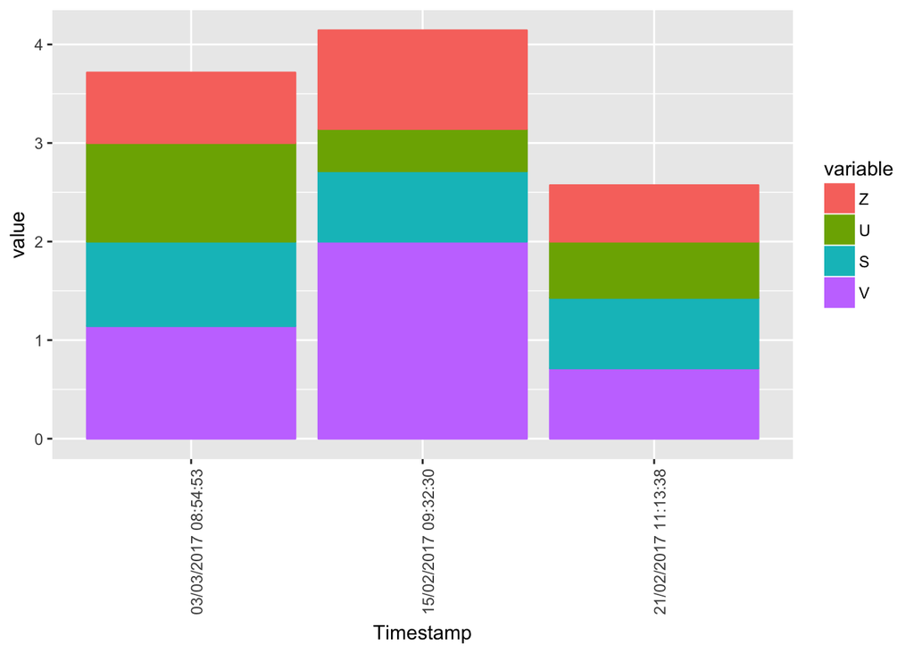

```r
meanPlot <- ggplot(meltMeans) +
  geom_col(aes(x = Timestamp, y = value, col = variable, fill = variable)) +
  theme(axis.text.x = element_text(angle=90))

meanPlot
```

**De opdracht voor deze oefening luidt:** Vul het formulier opnieuw in en bouw een grafiek met alleen jouw eigen data. Op de x-as staan de timestamps.